# TWD - praca domowa 2

Marcel Witas

31-10-2021

## Wizualizacja do poprawy

Wykres pochodzi z Twittera. Został tam umieszczony 30 października przez użytkownika “Piłkarskie Statystyki / Robert”, z następującym opisem: “Aż 1 na 4 klub #Ekstraklasa kończy przygodę po jednym sezonie, a ponad połowa spada w pierwszych 3 sezonach po awansie do najwyższej klasy rozgrywkowej.” Dotyczy polskich klubów piłkarskich. Ma odpowiadać na pytanie o czas, jaki drużyna po awansie do najwyższej klasy rozgrywkowej w niej grała.

$~$

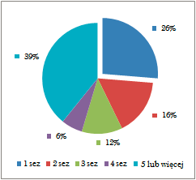

https://twitter.com/zagrosik/status/1454439242852089864

$~$

## Kod i wizualizacja

```r
df <- data.frame(sezon = c("1", "2", "3", "4", "5 lub więcej"), po = c(26, 16, 12, 5.9, 39))

sezony <- df %>%
  mutate(procent = round(po*100 / sum(df$po), 1) )
```

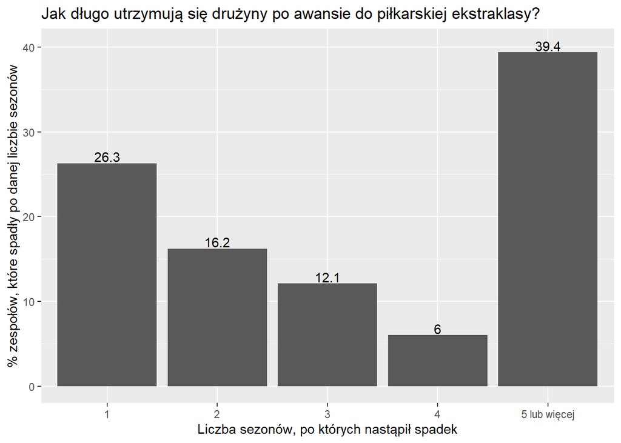

```r
ggplot(sezony, aes(x = sezon, y = procent)) +
  geom_col() +
  labs(title = "Jak długo utrzymują się drużyny po awansie do piłkarskiej ekstraklasy?",
       x = "Liczba sezonów, po których nastąpił spadek",
       y = "% zespołów, które spadły po danej liczbie sezonów") +
  geom_text(aes(label = procent, y = procent + 0.8) )
```

$~$

## Uzasadnienie

Wykres jest lepszy, niż oryginalny z kilku powodów.

Po pierwsze, na wizualizacji użytkownika Twittera procenty nie sumują się do 100. Z powodu braku dostępu do oryginalnych danych, przeskalowałem wartości podane na pierwszym wykresie, zdecydowałem się podać je z dokładnością do jednego miejsca po przecinku.

Po drugie, oryginalny wykres jest kołowy, co często zmniejsza czytelność. Ja zdecydowałem się na wykres kolumnowy.

Kolejnym aspektem są kolory. Zostały użyte dwa odcienie niebieskiego, które oczywiście można rozróżnić, natomiast w legendzie występują po przeciwnych stronach niż na wykresie, co może prowadzić do odczytania ich w zły sposób. Na poprawionym wykresie znajduje się tylko jeden kolor, co eliminuje ryzyko błędnego odczytania danych z tego powodu.

Na nowym wykresie słupki nie są posortowane, natomiast w tym wypadku kolejność podyktowana liczbą sezonów wydaje się odpowiedniejsza.